# Nutritional Deficit: A Comprehensive Global Investigation

| NAME | STUDENT_NO | COURSE_NAME |
| --- | --- | --- |
| PRAYAG MALHOTRA | 22267468 | MSSM |

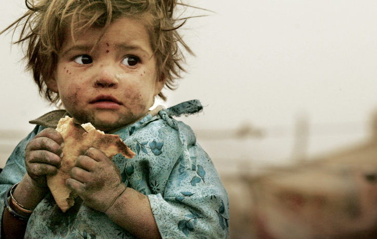

# **INTRODUCTION**

The project, “Nutritional Deficit: A Comprehensive Global Investigation,” delves into the pressing issue of global malnutrition. By employing robust datasets, the project provides insights into the prevalence of malnutrition across various countries, the distribution of population among different continents, and the impact of these factors on life expectancy. The period of focus is from 2000 to 2021, providing a valuable longitudinal perspective on these vital health determinants.

## **WORLD MAP : Global Malnutrition Distribution**

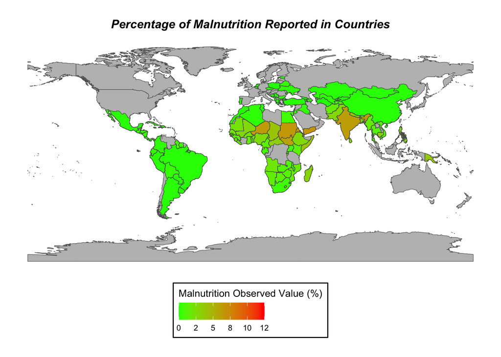

The world map displays the prevalence of malnutrition among the population in different countries, represented as a percentage. The gradient bar illustrates the level of malnutrition reported in each country, with nations in Asia and Africa, including India, Sudan, and Chad, exhibiting higher levels of malnutrition compared to those in Europe and America.

## **BAR CHART : Population Breakdown by Continent**

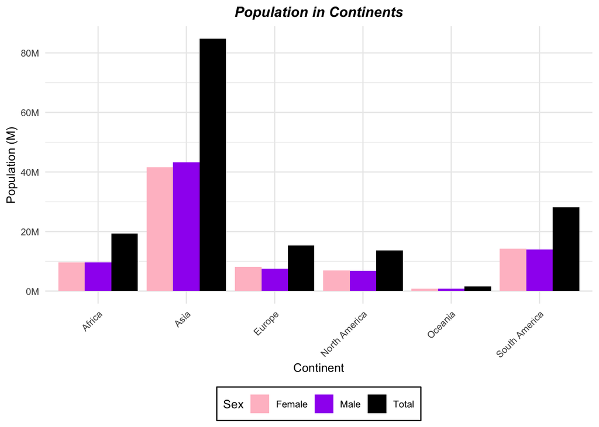

The bar chart provides a visual representation of the mean population across different continents between the years 2000 and 2021. The data reveals that Asia has the most substantial population compared to other continents, and is higher than the population of Europe, North America, and Oceania combined.

## **SCATTER PLOT : Continental Malnutrition Trends**

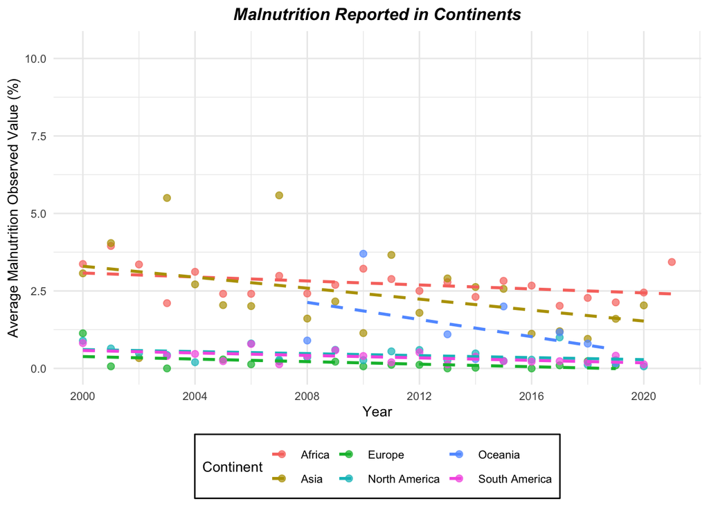

## **TIME SERIES : Life Expectancy Progression**

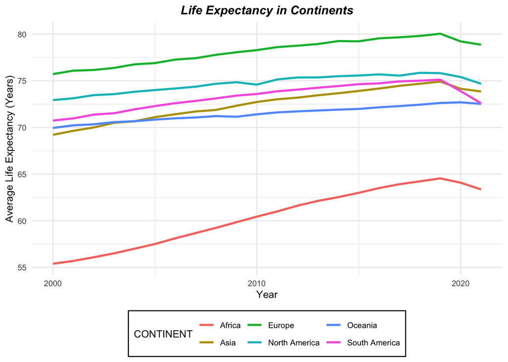

The time series chart illustrates the changes in life expectancy across different continents from 2000 to 2021. The data reveals that Africa has the lowest life expectancy compared to other continents, which exhibit significant differences. Moreover, the chart indicates a decline in life expectancy after 2019 in all continents except Oceania. This could be a potential consequence of the COVID-19 pandemic.

# **CONCLUSION**

The findings from this investigation illuminate the multifaceted nature of global malnutrition. The data underscores the critical importance of addressing malnutrition to improve population health and life expectancy. While there have been some strides made, the persistence of significant disparities is evident from the data. This research emphasizes the urgent need for comprehensive, targeted strategies, and international collaboration to mitigate malnutrition and enhance global health outcomes.

[figure not shown]

[figure not shown]